# Differential Gene Expression Analysis

shaistamadad

5/2/2020

```r
#install.packages("statmod")
```

## Load libraries

```r
library("dplyr")  # for arrange() function
library(limma)    # main limma package
library(edgeR)    # we need the TMM function from edgeR
```

```r
library(WriteXLS) # for convenience, we will save the final results as an Excel file
library(pheatmap) # for heatmap plot
library(statmod)
```

## Load raw data

This is the RNA-seq counts per gene. This was calculated using featureCounts

#DGE with the Weight Gain Group only divided into 2 groups based on sample IDs/ clustering

```r
load(file="WeightGainTotalCountsNCBI.RData")
WeightGainCounts= read_counts_data
#head(WeightGainCounts)
```

Convert counts from standard R list to Bioconductor DGEList data structure

```r
dge_unfiltered <- DGEList(counts=WeightGainCounts)
```

```r
Counts=dge_unfiltered$counts
```

## Non-specific filter to remove low count features

```r
# (requires > 1 CPM over at least 3 samples)
#isexpr <- rowSums(cpm(dge) > 1) >=3  # require a minimum counts per million
isexpr <- rowSums(dge_unfiltered$counts > 1) >=3  # or we can specify a minimum count

# Check what fraction of genes remain
sum(isexpr)/nrow(dge_unfiltered)
```

```
## [1] 0.6319216
```

```r
# Remove low expressed genes.
dge_filtered <- dge_unfiltered[isexpr,,keep.lib.sizes=FALSE] # keep.lib.sizes=FALSE to force recalculating library sizes from sums of column counts (note: we can also pass in library sizes explicitly)

dim(dge_filtered)
```

```
## [1] 24365    36
```

## TMM normalization

```r
dge_normalised <- calcNormFactors(dge_filtered, method="TMM")
```

```r
save(dge_normalised, file= "Dataset_WG.csv")
```

```r
# (requires > 1 CPM over at least 3 samples)
#isexpr <- rowSums(cpm(dge) > 1) >=3  # require a minimum counts per million
isexpr_gs <- rowSums(WeightGainCounts> 1) >=3  # or we can specify a minimum count

# Check what fraction of genes remain
sum(isexpr_gs)/nrow(WeightGainCounts)
```

```
## [1] 0.6319216
```

```r
# Remove low expressed genes.
dge_filtered_gs <- WeightGainCounts[isexpr_gs,] # keep.lib.sizes=FALSE to force recalculating library sizes from sums of column counts (note: we can also pass in library sizes explicitly)

dim(dge_filtered_gs)
```

```
## [1] 24365    36
```

## Calculate design matrix

```r
library(readr)
Experiment_Design <- read_csv("Experiment_Design_WG.csv")
Experiment_Design= as.data.frame(Experiment_Design)
head(Experiment_Design)
```

```
##   stressor               name
## 1      WGB C23ELACXX_8_19.bam
## 2      WGB C2LRRACXX_1_18.bam
## 3      WGB C2LRRACXX_1_22.bam
## 4      WGA C6KALANXX_1_27.bam
## 5      WGB C6KALANXX_5_15.bam
## 6      WGB  C6KALANXX_6_6.bam
```

```r
Experiment_Design$stressor <- as.factor(Experiment_Design$stressor)
#Experiment_Design$name<- as.factor(Experiment_Design$name)
str(Experiment_Design)  # check dataframe structure
```

```
## 'data.frame':    36 obs. of  2 variables:
##  $ stressor: Factor w/ 2 levels "WGA","WGB": 2 2 2 1 2 2 1 1 2 1 ...
##  $ name    : chr  "C23ELACXX_8_19.bam" "C2LRRACXX_1_18.bam" "C2LRRACXX_1_22.bam" "C6KALANXX_1_27.bam" ...
##  - attr(*, "spec")=
##   .. cols(
##   ..   stressor = col_character(),
##   ..   name = col_character()
##   .. )
```

```r
Experiment_Design$stressor <- relevel(Experiment_Design$stressor, "WGB")

design <- model.matrix(~stressor, data=Experiment_Design)  # get design matrix corresponding to a factorial model formula
```

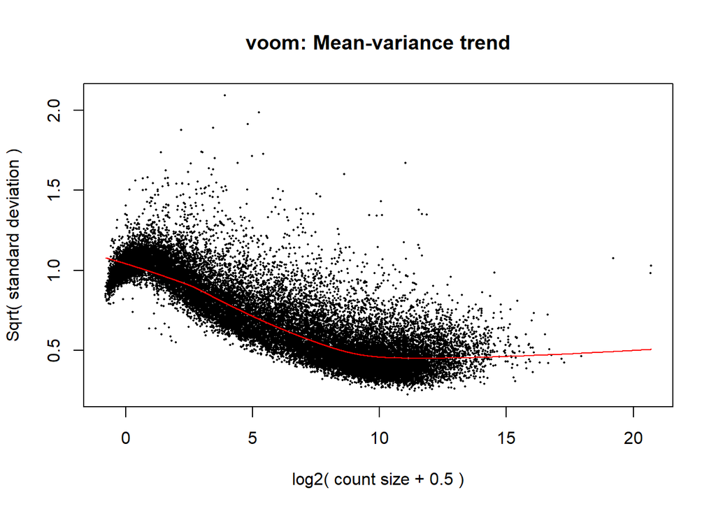

```r
v <- voom(dge_normalised,design,plot=TRUE) # Note: optionally, we can pass library sizes explicity here
```

```r
v$design
```

```
##    (Intercept) stressorWGA
## 1            1           0
## 2            1           0
## 3            1           0
## 4            1           1
## 5            1           0
## 6            1           0
## 7            1           1
## 8            1           1
## 9            1           0
## 10           1           1
## 11           1           1
## 12           1           1
## 13           1           0
## 14           1           1
```

[output cut: 27 more lines]

## Fit linear models across all genes using lmFit

(like lm() in base R)

```r
fit <- lmFit(v,design)
```

## eBayes computes F (overall “omnibus” p-values) and (moderated) t-statistics for all genes

(like anova() in base R)

```r
fit2  <- eBayes(fit, trend = TRUE, robust = TRUE)
colnames(fit2)
```

```
## [1] "(Intercept)" "stressorWGA"
```

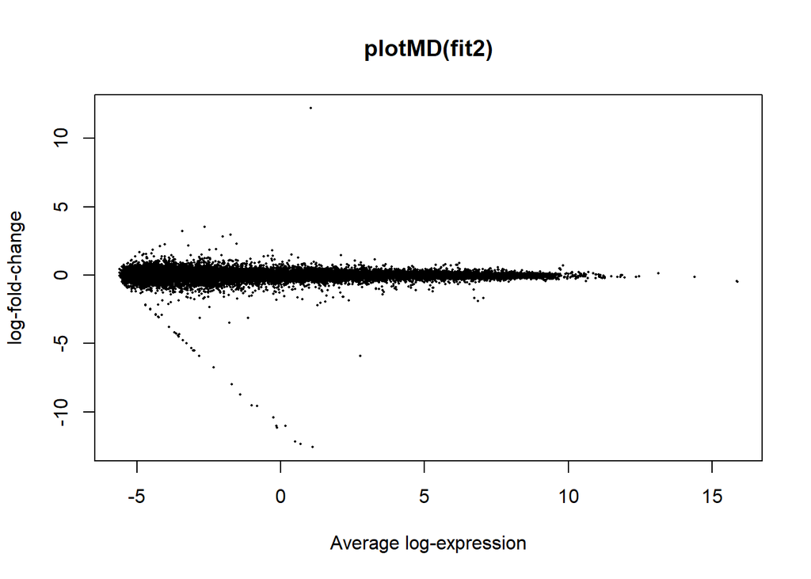

```r
plotMD(fit2, main="plotMD(fit2)", cex=0.5, coef="stressorWGA")
```

## As a diagnostic, it is useful to plot the distribution of raw p-values, to check whether there is a useful signal

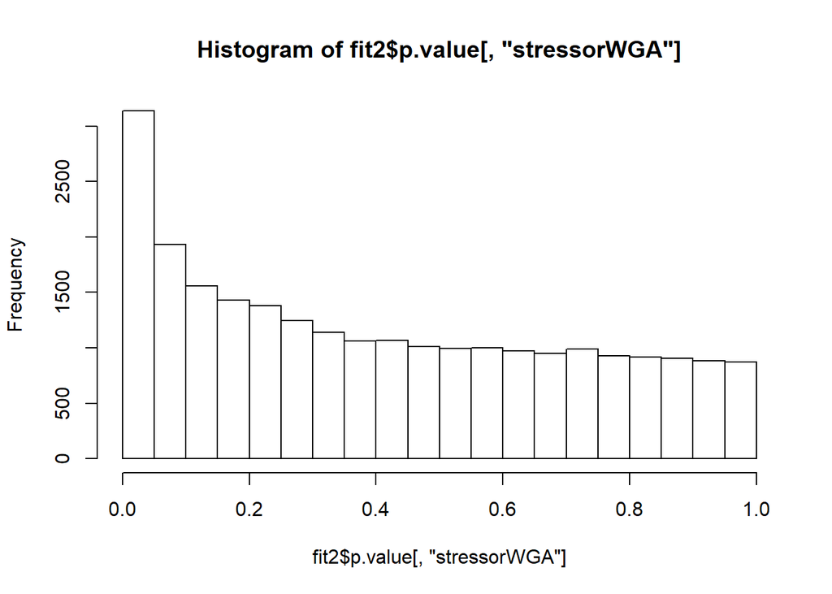

```r
hist(fit2$p.value[,"stressorWGA"]) # as an example, plot p-value distribution for one comparison
```

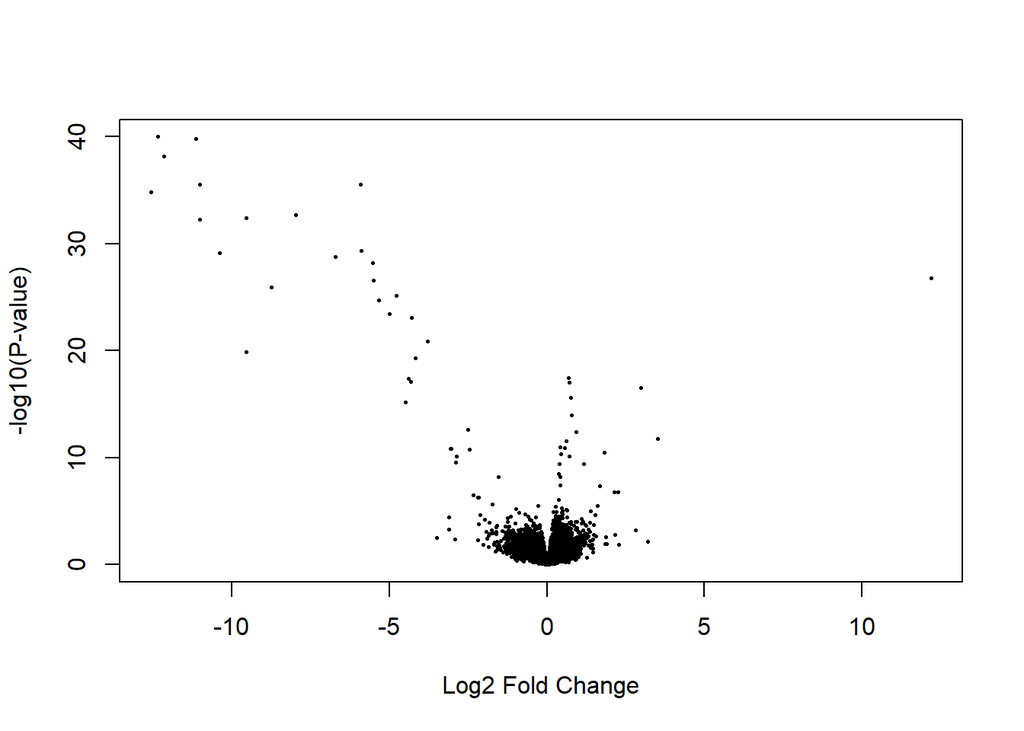

```r
volcanoplot(fit2, coef="stressorWGA")
```

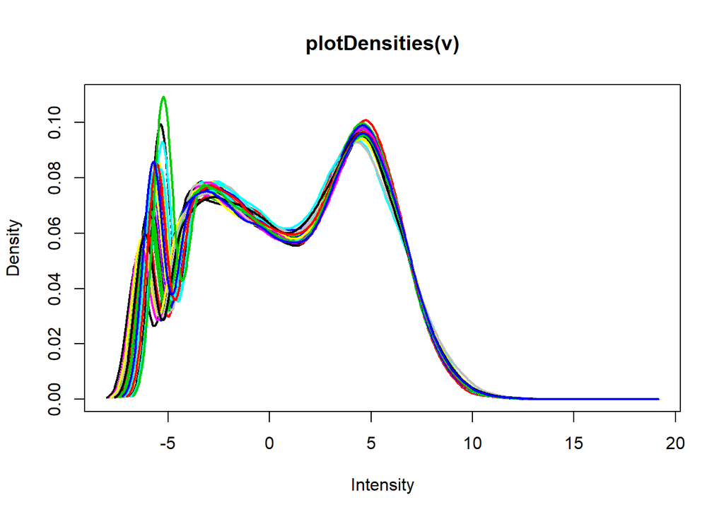

```r
plotDensities(v, main="plotDensities(v)",legend=F)
```

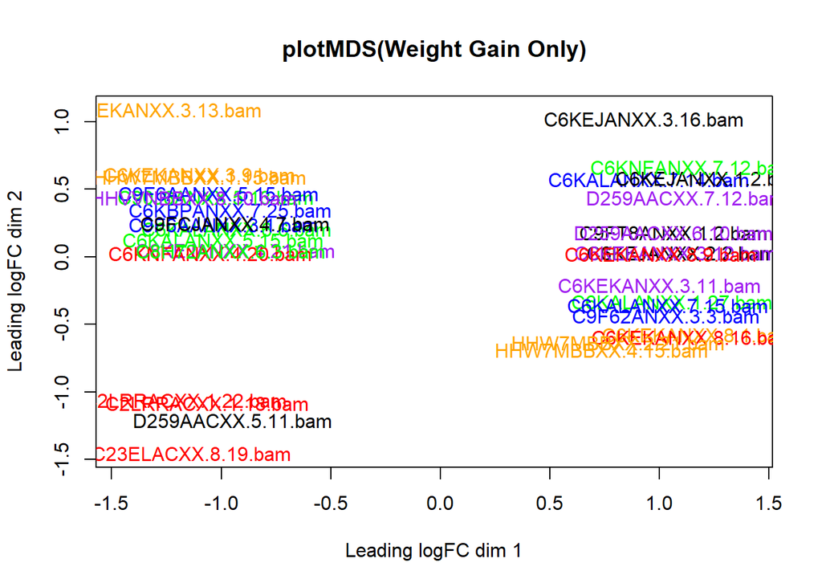

```r
plotMDS(v, main="plotMDS(Weight Gain Only)",cex=1,col=c(rep("red",3),rep("green",3),rep("blue",3),rep("black",3), rep("purple",3), rep("orange",3)))
```

## Do FDR multiple testing correction and extract list of most significant genes (using Benjamini-Hockberg by default)

```r
R_stressor = topTable(fit2, coef="stressorWGA", number=nrow(dge_normalised$counts))
```

## How many significant genes showing interaction are there at FDR of 5% ?

```r
WG_FDR=R_stressor[R_stressor$adj.P.Val<= .05,]
dim(R_stressor[R_stressor$adj.P.Val<= .05,])
```

```
## [1] 158   6
```

```r
write.csv(WG_FDR, file= "DGE_WGonly.csv")
```

```r
WG_FDR
```

```
##                    logFC     AveExpr          t      P.Value    adj.P.Val
## PRKY          -5.9166117  2.76341190 -46.457686 3.012723e-36 1.468100e-32
## DDX3Y        -12.3524326  0.68988715 -60.446576 9.989741e-41 1.754966e-36
## UTY          -11.1414479 -0.12562275 -59.886317 1.440563e-40 1.754966e-36
## KDM5D        -12.1498879  0.50156992 -54.383219 6.342031e-39 5.150786e-35
## TXLNGY       -11.0252470 -0.14736254 -46.520860 2.857090e-36 1.468100e-32
## RPS4Y1       -12.5725413  1.10185272 -44.537237 1.563218e-35 6.347967e-32
## USP9Y        -11.0325497  0.16954092 -38.324037 5.356119e-33 1.450021e-29
## TTTY15        -7.9652808 -1.71018948 -39.361463 1.903288e-33 6.624802e-30
## ZFY           -9.5539848 -0.83227800 -38.576638 4.153225e-33 1.264917e-29
## EIF1AY       -10.4018499 -0.25574682 -31.829592 6.818494e-30 1.510296e-26
## LINC00278     -5.9055014 -2.83927843 -32.185466 4.454770e-30 1.085405e-26
## TMSB4Y        -6.7239788 -2.33910398 -31.134188 1.586781e-29 3.221826e-26
## LOC107987346  -5.5203181 -3.01727875 -30.020688 6.367050e-29 1.193332e-25
## XIST          12.1970066  1.03233499  28.471553 1.531802e-27 2.665883e-24
## LOC107987347  -5.4951183 -3.04832473 -27.237879 2.549690e-27 4.141547e-24
## BCORP1        -8.7483916 -1.40815901 -26.182144 1.131008e-26 1.722313e-23
## LOC105377223  -4.7744190 -3.40031197 -24.953874 6.857331e-26 9.828168e-23
## PRY           -5.3337573 -3.12575150 -24.239138 2.029701e-25 2.747426e-22
## TTTY14        -5.0023979 -3.29192527 -22.431318 3.596931e-24 4.612590e-21
## LOC105377224  -4.2966837 -3.64546319 -21.893477 8.792488e-24 1.071145e-20
## ZFY-AS1       -3.7803118 -3.89890985 -19.082766 1.298967e-21 1.507111e-18
## LOC105377225  -9.5409323 -1.01444717 -18.540737 1.243068e-20 1.376698e-17
## PRY2          -4.1779647 -3.69964320 -17.227908 4.921627e-20 5.213715e-17
## KDM6A          0.6884523  5.92247797  15.241239 3.424911e-18 3.476998e-15
## ZFX            0.6990984  5.66902473  14.821607 8.831805e-18 7.969887e-15
## RPS4Y2        -4.3870262 -3.58450927 -15.192876 3.816364e-18 3.719429e-15
## NLGN4Y        -4.3098303 -3.52612283 -14.899717 7.393544e-18 6.928604e-15
## MAP7D2         2.9763557 -1.75597174  14.324597 2.779798e-17 2.418921e-14
## PRKX           0.7694395  6.09391361  13.391486 2.579546e-16 2.167264e-13
## TTTY10        -4.4944864 -3.55008512 -13.038614 6.150851e-16 4.995516e-13
## EIF1AX         0.7939010  5.73216205  11.905291 1.110744e-14 8.730091e-12
## LOC102724150  -2.5012634 -4.53849656 -10.746689 2.530980e-13 1.927104e-10
## LOC389906      0.9166537  2.78397905  10.588586 3.930135e-13 2.901750e-10
## HEPH           3.5154665 -2.65125874  10.045530 1.826470e-12 1.308881e-09
## PUDP           0.6203168  3.85220692   9.882287 2.920220e-12 2.032890e-09
## LOC102725532  -3.0312006 -4.26667740  -9.330165 1.464484e-11 9.390038e-09
## LOC101929148  -3.0721065 -4.24830007  -9.318214 1.517145e-11 9.478266e-09
## KDM5C          0.4123689  7.24524374   9.442156 1.052663e-11 7.124482e-09
## TXLNG          0.5675921  4.44581353   9.374062 1.286462e-11 8.471528e-09
```

[output cut: 263 more lines]

```
## ZNF737       -0.602788106
## NBEA         -0.608753813
## STARD3NL     -0.614923714
## CRYZ         -0.656150268
## PPP1R2       -0.673565913
## FBXO32       -0.682870409
## ST6GAL1      -0.702284478
## ZNF768       -0.763021333
## TNRC6C       -0.855094142
## TMEM106A     -0.872827337
## SCCPDH       -0.901183968
## ITGA6        -0.926590838
## TNFRSF10A    -0.962700628
## ARID5B       -0.999867764
## ST3GAL1      -1.192439934
```

# NoWeigtGain Group Only Differential Gene Analysis divided into two groups based on sample IDs

```r
load(file="NoWeightGainTotalCountsNCBI.RData")
#head(WeightGainCounts)
```

```r
NoweightGainCounts= read_counts_data_NWG
```

Convert counts from standard R list to Bioconductor DGEList data structure

```r
dge_unfiltered1 <- DGEList(counts=NoweightGainCounts)
```

## Non-specific filter to remove low count features

```r
# (requires > 1 CPM over at least 3 samples)
#isexpr <- rowSums(cpm(dge) > 1) >=3  # require a minimum counts per million
isexpr1 <- rowSums(dge_unfiltered1$counts > 1) >=3  # or we can specify a minimum count

# Check what fraction of genes remain
sum(isexpr1)/nrow(dge_unfiltered1)
```

```
## [1] 0.6427108
```

```r
# Remove low expressed genes.
dge_filtered1 <- dge_unfiltered1[isexpr1,,keep.lib.sizes=FALSE] # keep.lib.sizes=FALSE to force recalculating library sizes from sums of column counts (note: we can also pass in library sizes explicitly)

dim(dge_filtered1)
```

```
## [1] 24781    36
```

## TMM normalization

```r
dge_normalised1 <- calcNormFactors(dge_filtered1, method="TMM")
```

```r
dge_normalised1
```

```
## An object of class "DGEList"
## $counts
##             C23ELACXX.6.16.bam C23ELACXX.7.18.bam C23K9ACXX.7.4.bam
## DDX11L1                    552               1216               411
## WASH7P                    6773              15204              3899
## MIR6859-1                  165                357               120
## MIR1302-2HG                  7                  6                 1
## MIR1302-2                    0                  4                 2
##             C24A4ACXX.1.23.bam C2LRRACXX.4.21.bam C2LRRACXX.6.4.bam
## DDX11L1                     97                259               283
## WASH7P                    2647               4196              2612
## MIR6859-1                   75                101                97
## MIR1302-2HG                  3                  7                 0
## MIR1302-2                    0                  1                 0
##             C6KALANXX.2.21.bam C6KALANXX.5.14.bam C6KALANXX.5.16.bam
## DDX11L1                    100                154                138
## WASH7P                    1974               2030               1807
## MIR6859-1                   41                 67                 34
## MIR1302-2HG                  2                  4                  3
## MIR1302-2                    0                  0                  0
##             C6KALANXX.8.19.bam C6KBPANXX.1.16.bam C6KBPANXX.5.22.bam
## DDX11L1                    166                103                208
## WASH7P                    1719               1089               1599
## MIR6859-1                   40                 28                 39
## MIR1302-2HG                  2                  2                  4
## MIR1302-2                    1                  0                  3
##             C6KDCANXX.2.19.bam C6KDCANXX.3.22.bam C6KEJANXX.1.8.bam
## DDX11L1                    216                171               160
## WASH7P                    2066               1700              1315
## MIR6859-1                   67                 41                42
## MIR1302-2HG                  4                  6                 1
## MIR1302-2                    0                  0                 1
##             C6KEJANXX.8.23.bam C6KEKANXX.2.4.bam C6KEKANXX.3.12.bam
## DDX11L1                     44               114                180
## WASH7P                    1382              2187               1180
## MIR6859-1                   32                41                 21
## MIR1302-2HG                  1                 4                  0
## MIR1302-2                    0                 0                  0
##             C6KEKANXX.7.2.bam C6KNFANXX.4.21.bam C8VKEANXX.7.20.bam
## DDX11L1                    86                165                 61
```

[output cut: 29 more lines]

```
## DDX11L1                    237                102                180
## WASH7P                    2871               3486               1595
## MIR6859-1                   59                 70                 34
## MIR1302-2HG                  1                  2                  1
## MIR1302-2                    0                  0                  0
## 24776 more rows ...
##
## $samples
##                    group  lib.size norm.factors
## C23ELACXX.6.16.bam     1 102986317    1.0856929
## C23ELACXX.7.18.bam     1 154943471    1.0743587
## C23K9ACXX.7.4.bam      1  47920236    1.0283171
## C24A4ACXX.1.23.bam     1  39007189    0.9416667
## C2LRRACXX.4.21.bam     1  37273123    1.0944090
## 31 more rows ...
```

## Calculate design matrix

```r
library(readr)
Experiment_Design1 <- read_csv("Experiment_Design_NWG2.csv")
Experiment_Design1= as.data.frame(Experiment_Design1)
head(Experiment_Design1)
```

```
##   stressor               name
## 1     NWGA C23ELACXX_6_16.bam
## 2     NWGB C23ELACXX_7_18.bam
## 3     NWGA  C23K9ACXX_7_4.bam
## 4     NWGB C24A4ACXX_1_23.bam
## 5     NWGB C2LRRACXX_4_21.bam
## 6     NWGA  C2LRRACXX_6_4.bam
```

```r
Experiment_Design1$stressor <- as.factor(Experiment_Design1$stressor)
#Experiment_Design$name<- as.factor(Experiment_Design$name)
str(Experiment_Design1)  # check dataframe structure
```

```
## 'data.frame':    36 obs. of  2 variables:
##  $ stressor: Factor w/ 2 levels "NWGA","NWGB": 1 2 1 2 2 1 2 1 1 1 ...
##  $ name    : chr  "C23ELACXX_6_16.bam" "C23ELACXX_7_18.bam" "C23K9ACXX_7_4.bam" "C24A4ACXX_1_23.bam" ...
##  - attr(*, "spec")=
##   .. cols(
##   ..   stressor = col_character(),
##   ..   name = col_character()
##   .. )
```

```r
Experiment_Design1$stressor <- relevel(Experiment_Design1$stressor, "NWGB")

design1 <- model.matrix(~stressor, data=Experiment_Design1)  # get design matrix corresponding to a factorial model formula
head(design1)
```

```
##   (Intercept) stressorNWGA
## 1           1            1
## 2           1            0
## 3           1            1
## 4           1            0
## 5           1            0
## 6           1            1
```

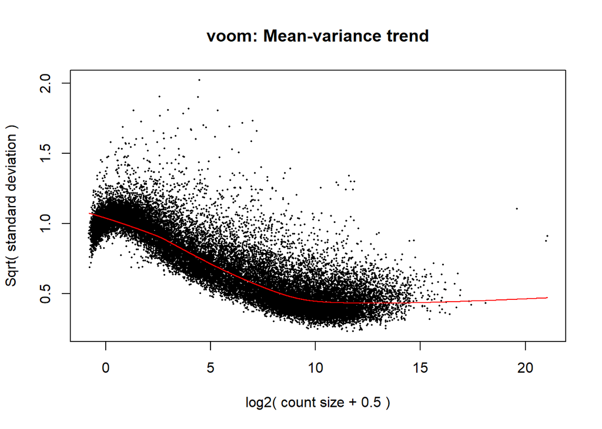

```r
v1 <- voom(dge_normalised1,design1,plot=TRUE) # Note: optionally, we can pass library sizes explicity here
```

```r
v1$design
```

```
##    (Intercept) stressorNWGA
## 1            1            1
## 2            1            0
## 3            1            1
## 4            1            0
## 5            1            0
## 6            1            1
## 7            1            0
## 8            1            1
## 9            1            1
## 10           1            1
## 11           1            0
## 12           1            0
## 13           1            1
## 14           1            1
```

[output cut: 27 more lines]

## Fit linear models across all genes using lmFit

(like lm() in base R)

```r
fit1 <- lmFit(v1,design1)
```

## eBayes computes F (overall “omnibus” p-values) and (moderated) t-statistics for all genes

(like anova() in base R)

```r
fit2.1  <- eBayes(fit1)
colnames(fit2.1)
```

```
## [1] "(Intercept)"  "stressorNWGA"
```

## Do FDR multiple testing correction and extract list of most significant genes (using Benjamini-Hockberg by default)

```r
R_stressor1 = topTable(fit2.1, coef="stressorNWGA", number=nrow(dge_normalised1$counts))
```

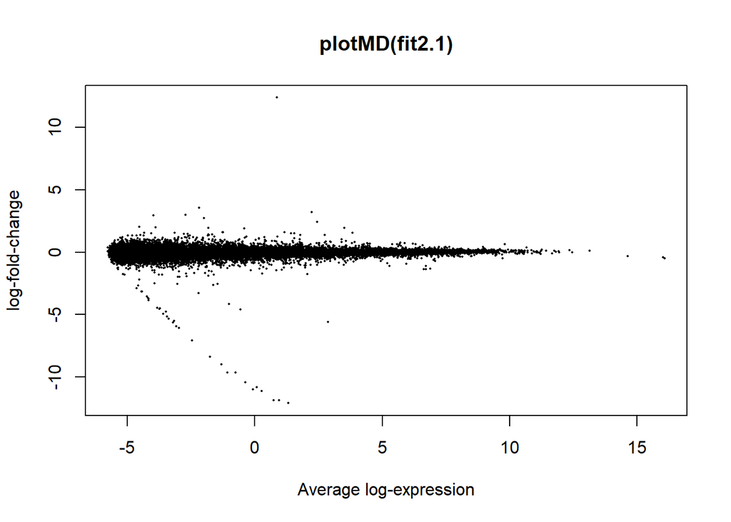

```r
plotMD(fit2.1, main="plotMD(fit2.1)", cex=0.5, coef="stressorNWGA")
```

## How many significant genes showing interaction are there at FDR of 5% ?

```r
FDR_NWG= R_stressor1[R_stressor1$adj.P.Val<= .05,]

dim(R_stressor1[R_stressor1$adj.P.Val<= .05,])
```

```
## [1] 132   6
```

```r
#head(R_stressor1)
```

```r
write.csv(FDR_NWG, "NWG_Only.csv")
```

```r
FDR_NWG
```

```
##                    logFC     AveExpr          t      P.Value    adj.P.Val
## PRKY          -5.6173762  2.86911958 -50.694991 4.682654e-37 1.160408e-32
## ZFY           -9.6534799 -0.75559031 -44.651060 5.929651e-35 7.347134e-31
## DDX3Y        -11.8555527  0.94489331 -40.927537 1.620188e-33 8.911851e-30
## USP9Y        -11.1132130  0.26121702 -40.922043 1.628456e-33 8.911851e-30
## TXLNGY       -10.9863083 -0.07949647 -40.815215 1.798122e-33 8.911851e-30
## KDM5D        -11.8784926  0.73566260 -39.518670 6.109045e-33 2.162689e-29
## RPS4Y1       -12.0994167  1.32174181 -37.897146 2.979387e-32 9.229025e-29
## TTTY15        -8.3827707 -1.75891981 -40.156379 3.331801e-33 1.376089e-29
## UTY          -10.8068609  0.07586793 -36.597417 1.112237e-31 2.947685e-28
## EIF1AY       -10.4523395 -0.37281144 -36.532298 1.189494e-31 2.947685e-28
## BCORP1        -8.9965894 -1.30240496 -32.516446 9.456550e-30 2.130389e-26
## TMSB4Y        -7.0842486 -2.47135669 -31.603415 2.743591e-29 5.665744e-26
## LOC107987346  -5.6468610 -3.21847436 -29.206094 5.181444e-28 9.877028e-25
## LOC105377223  -5.3160467 -3.36979838 -29.116717 5.805858e-28 1.027678e-24
## XIST          12.3859232  0.86668980  26.528330 1.813045e-26 2.995271e-23
## LINC00278     -6.0690194 -2.98413071 -26.336607 2.367478e-26 3.666779e-23
## LOC107987347  -5.5161559 -3.16900587 -26.109590 3.254439e-26 4.744015e-23
## TTTY10        -4.5620182 -3.73579408 -24.877913 1.911895e-25 2.632149e-22
## PRY           -5.9436339 -3.08952224 -23.994522 7.145894e-25 8.854120e-22
## TTTY14        -5.1423392 -3.44032119 -24.152461 5.627776e-25 7.340101e-22
## NLGN4Y        -4.7846947 -3.48930929 -19.594377 1.024519e-21 1.208981e-18
## PRY2          -4.9494107 -3.58461803 -19.477940 1.264312e-21 1.424132e-18
## LOC105377224  -4.5117121 -3.72911667 -19.358561 1.570224e-21 1.691814e-18
## RPS4Y2        -4.4577110 -3.82531991 -17.633100 4.087232e-20 4.220238e-17
## LOC105377225  -9.6666805 -1.07527046 -16.794072 2.185883e-19 2.166734e-16
## ZFY-AS1       -3.5683122 -4.23690959 -15.722511 2.047041e-18 1.951066e-15
## MAP7D2         3.5348655 -2.19185813  14.623894 2.286072e-17 2.098191e-14
## KDM6A          0.7232348  5.88370248  14.367265 4.091691e-17 3.621292e-14
## EIF1AX         0.7609115  5.70923274  12.883373 1.371178e-15 1.171695e-12
## HEPH           3.0020962 -2.71406532  11.986242 1.301403e-14 1.075002e-11
## PUDP           0.7174753  3.80804208  11.973017 1.346306e-14 1.076220e-11
## FAM224A       -3.6587121 -4.18294065 -11.820605 1.993463e-14 1.543750e-11
## FAM224B       -3.7135317 -4.15926627 -11.757681 2.346156e-14 1.729207e-11
## LOC102725532  -3.8339904 -4.16909429 -11.753375 2.372505e-14 1.729207e-11
## TSIX           2.9541127 -3.98142472  11.710306 2.653184e-14 1.878530e-11
## LOC101929148  -3.8664257 -4.16641449 -10.982729 1.818470e-13 1.217933e-10
## ZFX            0.5900742  5.66333869  10.989796 1.784202e-13 1.217933e-10
## ZRSR2          0.5113654  4.49553494  10.908671 2.220529e-13 1.448077e-10
## LOC112268311  -2.8759064 -4.63183211 -10.404366 8.819084e-13 5.603736e-10
```

[output cut: 211 more lines]

```
## CASK         -0.21182390
## FRG1BP       -0.23107733
## TMEM200A     -0.25265701
## TAGAP        -0.25867701
## HLA-DRB6     -0.28695387
## PC           -0.32527547
## KCNMB1       -0.35295696
## ATP9A        -0.46120157
## LOC728554    -0.57925553
## FAAH         -0.63744487
## USP9X        -0.65496973
## FBXL16       -0.84104987
## HCAR3        -0.86277200
## CDK16        -0.92689784
## ELK3         -1.15272892
```

```r
png(file="mygraphic3.png",width=1000,height=750)
plotMDS(v1, main="(No Weight Gain Clusters)",cex=1,col=c(rep("red",3),rep("green",3),rep("blue",3),rep("black",3), rep("purple",3), rep("orange",3)))
#dev.off()
```

```r
NoweightGain= read_counts_data_NWG
TotalCountsNCBI= cbind(WeightGainCounts,NoweightGain)
save(TotalCountsNCBI, file = "TotalCountsNCBI.RData")
```

```r
df= as.data.frame(TotalCountsNCBI)
head(df)
```

```
##             C23ELACXX.8.19.bam C2LRRACXX.1.18.bam C2LRRACXX.1.22.bam
## DDX11L1                     92                279                126
## WASH7P                    3311               2206               2532
## MIR6859-1                   91                 60                 79
## MIR1302-2HG                  3                  2                  2
## MIR1302-2                    0                  0                  0
## FAM138A                      0                  0                  1
##             C6KALANXX.1.27.bam C6KALANXX.5.15.bam C6KALANXX.6.6.bam
## DDX11L1                    137                371               110
## WASH7P                    1372               1805              1287
## MIR6859-1                   34                 59                49
## MIR1302-2HG                  2                  2                 2
## MIR1302-2                    1                  0                 0
## FAM138A                      0                  3                 3
##             C6KALANXX.7.14.bam C6KALANXX.7.15.bam C6KBPANXX.7.25.bam
## DDX11L1                    388                277                123
## WASH7P                    1386               1823                822
## MIR6859-1                   27                 44                 19
## MIR1302-2HG                  1                  3                  0
## MIR1302-2                    0                  1                  0
## FAM138A                      0                  1                  0
##             C6KEJANXX.1.2.bam C6KEJANXX.2.2.bam C6KEJANXX.3.16.bam
## DDX11L1                   143               145                179
## WASH7P                   1221              2248               2880
## MIR6859-1                  34                52                 67
## MIR1302-2HG                 2                 4                  5
## MIR1302-2                   0                 0                  0
## FAM138A                     0                 0                  1
##             C6KEJANXX.4.21.bam C6KEKANXX.3.10.bam C6KEKANXX.3.11.bam
## DDX11L1                     68                 58                180
## WASH7P                    1096               1960               2022
## MIR6859-1                   39                 57                 56
## MIR1302-2HG                  3                  5                  3
## MIR1302-2                    1                  0                  0
## FAM138A                      0                  1                  0
##             C6KEKANXX.3.13.bam C6KEKANXX.3.9.bam C6KEKANXX.8.1.bam
## DDX11L1                     95               118                74
## WASH7P                    2214              2014              1802
## MIR6859-1                   56                33                39
## MIR1302-2HG                  2                 5                 4
```

[output cut: 113 more lines]

```
## FAM138A                      3                 0                 0
##             D259AACXX.2.6.bam HHVVNBBXX.8.9.bam HHW7MBBXX.1.14.bam
## DDX11L1                   220               431                140
## WASH7P                   1784              3072               1373
## MIR6859-1                  38                72                 30
## MIR1302-2HG                 2                 5                  2
## MIR1302-2                   0                 1                  0
## FAM138A                     1                 0                  0
##             HHW7MBBXX.4.20.bam HHW7MBBXX.4.22.bam HHW7MBBXX.7.27.bam
## DDX11L1                    237                102                180
## WASH7P                    2871               3486               1595
## MIR6859-1                   59                 70                 34
## MIR1302-2HG                  1                  2                  1
## MIR1302-2                    0                  0                  0
## FAM138A                      0                  1                  1
```

```r
dim(df)
```

```
## [1] 38557    72
```

Convert counts from standard R list to Bioconductor DGEList data structure

```r
dge_total <- DGEList(counts=TotalCountsNCBI)
```

## Non-specific filter to remove low count features

```r
# (requires > 1 CPM over at least 3 samples)
#isexpr <- rowSums(cpm(dge) > 1) >=3  # require a minimum counts per million
isexprtotal <- rowSums(dge_total$counts > 5) >=3  # or we can specify a minimum count

# Check what fraction of genes remain
sum(isexprtotal)/nrow(dge_total)
```

```
## [1] 0.5484607
```

```r
# Remove low expressed genes.
dge_filtered_total <- dge_total[isexprtotal,,keep.lib.sizes=FALSE] # keep.lib.sizes=FALSE to force recalculating library sizes from sums of column counts (note: we can also pass in library sizes explicitly)

dim(dge_filtered_total)
```

```
## [1] 21147    72
```

## TMM normalization

```r
dge_normalised_total <- calcNormFactors(dge_filtered_total, method="TMM")
```

## Calculate design matrix

```r
library(readr)
Experiment_Design_total <- read_csv("Experiment_Design_Final1.csv")
Experiment_Design_total= as.data.frame(Experiment_Design_total)
(Experiment_Design_total)
```

```
##    stressor               name
## 1        WG C23ELACXX_8_19.bam
## 2        WG C2LRRACXX_1_18.bam
## 3        WG C2LRRACXX_1_22.bam
## 4        WG C6KALANXX_1_27.bam
## 5        WG C6KALANXX_5_15.bam
## 6        WG  C6KALANXX_6_6.bam
## 7        WG C6KALANXX_7_14.bam
## 8        WG C6KALANXX_7_15.bam
## 9        WG C6KBPANXX_7_25.bam
## 10       WG  C6KEJANXX_1_2.bam
## 11       WG  C6KEJANXX_2_2.bam
## 12       WG C6KEJANXX_3_16.bam
## 13       WG C6KEJANXX_4_21.bam
## 14       WG C6KEKANXX_3_10.bam
```

[output cut: 58 more lines]

```r
Experiment_Design_total$stressor <- as.factor(Experiment_Design_total$stressor)
#Experiment_Design$name<- as.factor(Experiment_Design$name)
str(Experiment_Design_total)  # check dataframe structure
```

```
## 'data.frame':    72 obs. of  2 variables:
##  $ stressor: Factor w/ 2 levels "NWG","WG": 2 2 2 2 2 2 2 2 2 2 ...
##  $ name    : chr  "C23ELACXX_8_19.bam" "C2LRRACXX_1_18.bam" "C2LRRACXX_1_22.bam" "C6KALANXX_1_27.bam" ...
##  - attr(*, "spec")=
##   .. cols(
##   ..   stressor = col_character(),
##   ..   name = col_character()
##   .. )
```

```r
Experiment_Design_total$stressor <- relevel(Experiment_Design_total$stressor, "NWG")

design_total <- model.matrix(~stressor, data=Experiment_Design_total)  # get design matrix corresponding to a factorial model formula
```

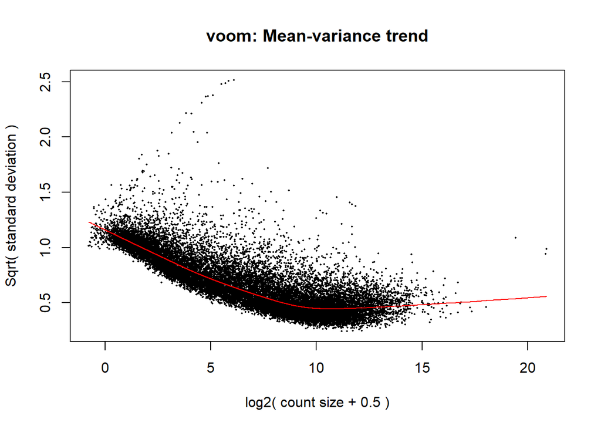

```r
v.total <- voom(dge_normalised_total,design_total,plot=TRUE) # Note: optionally, we can pass library sizes explicity here
```

## Fit linear models across all genes using lmFit

(like lm() in base R)

```r
fit.total <- lmFit(v.total,design_total)
```

## eBayes computes F (overall “omnibus” p-values) and (moderated) t-statistics for all genes

(like anova() in base R)

```r
fit2.total  <- eBayes(fit.total, trend = TRUE, robust = TRUE)
colnames(fit2.total)
```

```
## [1] "(Intercept)" "stressorWG"
```

## Do FDR multiple testing correction and extract list of most significant genes (using Benjamini-Hockberg by default)

```r
R_stressor.total = topTable(fit2.total, coef="stressorWG", number=nrow(dge_normalised_total$counts))
```

## How many significant genes showing interaction are there at FDR of 5% ?

```r
FDR.Total=R_stressor.total[R_stressor.total$adj.P.Val<= .05,]
dim(R_stressor.total[R_stressor.total$adj.P.Val<= .05,])
```

```
## [1] 62  6
```

```r
#head(R_stressor)
```

```r
write.csv(FDR.Total, file = "WG_NWG_Total.csv")
```

```r
FDR.Total
```

```
##                   logFC     AveExpr         t      P.Value    adj.P.Val
## LOC100653133  1.1399586  0.88913587  6.424932 1.134294e-08 0.0002398691
## LOC105375130 -2.9552905  0.15580376 -5.999010 7.356996e-08 0.0007778920
## LOC105370969  0.7078606 -0.71035995  5.374112 8.387459e-07 0.0059123198
## LOC105378184 -0.7486619  3.98605129 -5.122378 2.408092e-06 0.0098250402
## EZR          -0.2073144  7.31640196 -5.070495 2.787641e-06 0.0098250402
## JAKMIP1      -0.5366502  2.58894803 -5.014324 3.498058e-06 0.0105676325
## BSPRY        -0.8331915 -1.08067694 -5.215564 1.575954e-06 0.0083316747
## OSBPL10      -0.5049019  3.04711972 -4.943559 4.618971e-06 0.0108530422
## FBXO10       -0.2878628  2.23439429 -4.835082 6.930221e-06 0.0130380793
## LOC105376505  1.0643236  3.60792643  4.836840 7.325788e-06 0.0130380793
## LOC105376504  0.8791772  1.30512574  4.812625 7.725677e-06 0.0130380793
## LOC105378187 -0.6665286  3.28388022 -4.805866 8.015086e-06 0.0130380793
## PAXBP1-AS1    0.3838071  0.99120280  4.657979 1.357166e-05 0.0199348399
## LOC105376412 -1.1975352 -2.08580735 -4.968334 4.148457e-06 0.0108530422
## DMWD         -0.2570539  3.55073700 -4.613696 1.602555e-05 0.0199348399
## KLF11        -0.3151637  4.34841748 -4.630159 1.509992e-05 0.0199348399
## GDF7         -0.7754223  1.23391540 -4.597701 1.724745e-05 0.0202628781
## LOC105372793  0.5129866  0.28266309  4.621268 1.557736e-05 0.0199348399
## ZBTB32       -0.5013803  1.02270110 -4.556920 1.980923e-05 0.0220476720
## MIR8071-2    -0.7511629  1.35481454 -4.521819 2.287343e-05 0.0241852245
## TBXA2R        0.4206336  1.49855561  4.478289 2.651137e-05 0.0246801194
## SIGLEC6      -0.4323289  2.13885347 -4.457900 2.858068e-05 0.0246801194
## ZNF860       -0.4523846  1.81386776 -4.425759 3.216429e-05 0.0246801194
## EML6         -0.4679643  1.81352780 -4.423824 3.239331e-05 0.0246801194
## COCH         -0.7371320  0.79227494 -4.428996 3.199675e-05 0.0246801194
## SNHG16        0.2546211  5.16960282  4.473482 2.698574e-05 0.0246801194
## TRIB3        -0.2470115  3.04787475 -4.406822 3.447557e-05 0.0251398199
## RAPGEF1      -0.1777538  7.65971441 -4.437699 3.078491e-05 0.0246801194
## LOC101927432  0.7341723  0.02718566  4.388326 3.688800e-05 0.0256503152
## SYNPO        -0.4657639  2.48172856 -4.334461 4.505740e-05 0.0286250912
## COL4A3       -0.5004200  1.70377761 -4.312700 4.856548e-05 0.0286658007
## TNFRSF13B    -0.6033207  1.53207191 -4.293788 5.229752e-05 0.0298901544
## KNSTRN        0.2933556  2.44483935  4.266192 5.744447e-05 0.0319678465
## FAN1          0.2541855  4.89315024  4.311371 4.879977e-05 0.0286658007
## LOC105379504  0.4818905 -0.06025446  4.253471 6.013428e-05 0.0326066547
## OSBPL1A       0.3314534  3.08582234  4.196103 7.385130e-05 0.0370845386
## FA2H         -0.7701356 -1.78401416 -4.383080 3.760154e-05 0.0256503152
## SYT11        -0.2665651  4.89565711 -4.219853 6.792539e-05 0.0358367844
## LOC102724971 -0.6349577 -0.12491054 -4.183810 7.716081e-05 0.0370845386
```

[output cut: 71 more lines]

```
## WWOX         1.0166738
## GRIK4        0.9783992
## LOC105372321 0.9022989
## SREBF1       0.8791078
## COL4A4       0.8779466
## LAMA5        0.8589315
## LOC105371453 0.8571884
## PYHIN1       0.7874965
## NIPA1        0.7417890
## SIX5         0.7410000
## SH2D2A       0.7326883
## NODAL        0.6524783
## TRPV6        0.6408206
## SEL1L3       0.5933693
## APOBEC3G     0.5748968
```

## As a diagnostic, it is useful to plot the distribution of raw p-values, to check whether there is a useful signal

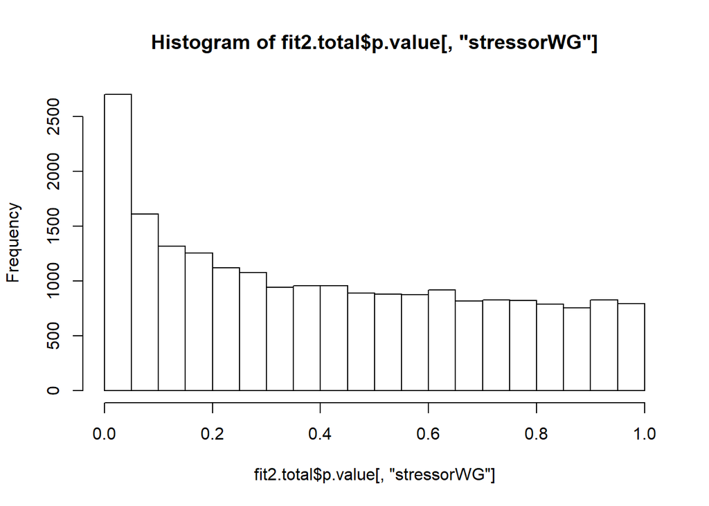

```r
hist(fit2.total$p.value[,"stressorWG"]) # as an example, plot p-value distribution for one comparison
```

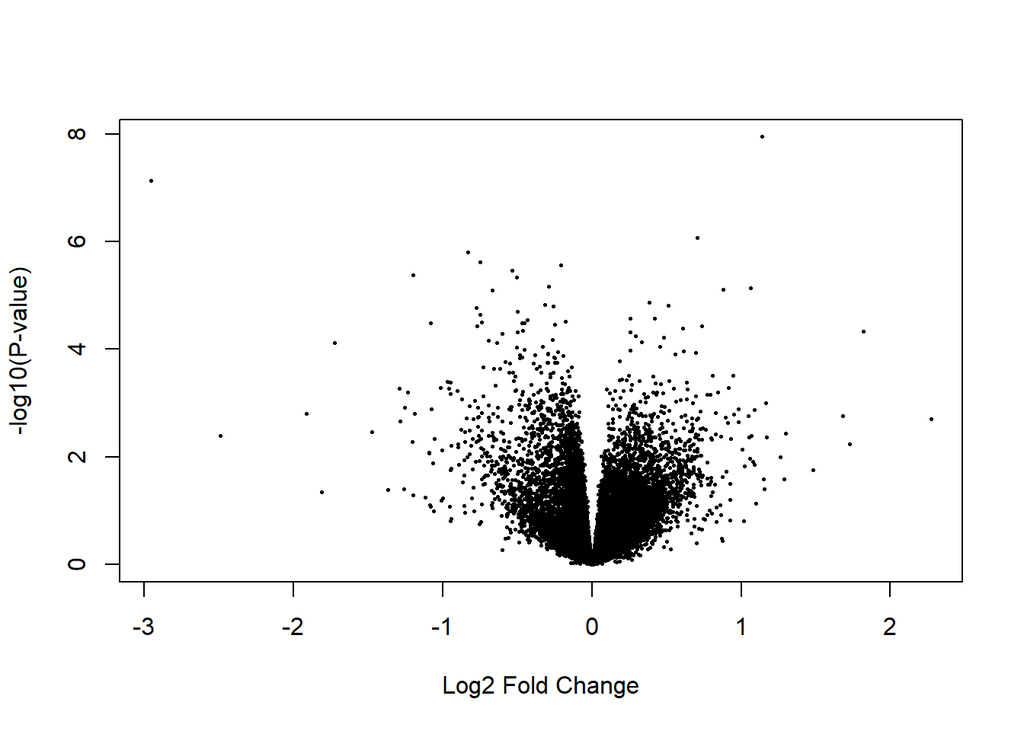

```r
volcanoplot(fit2.total, coef="stressorWG")
```

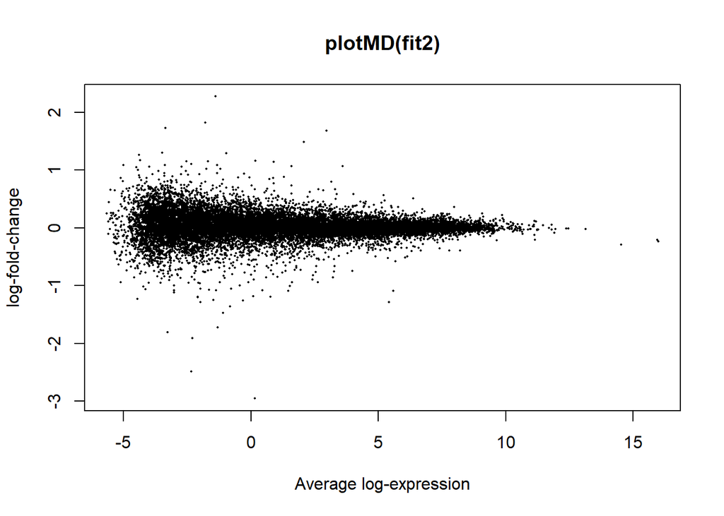

```r
plotMD(fit2.total, main="plotMD(fit2)", cex=0.5, coef="stressorWG")
```

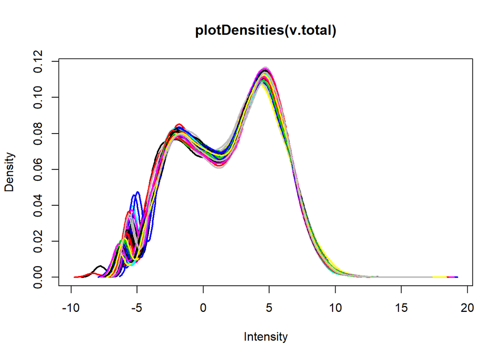

```r
plotDensities(v.total, main="plotDensities(v.total)",legend=F)
```

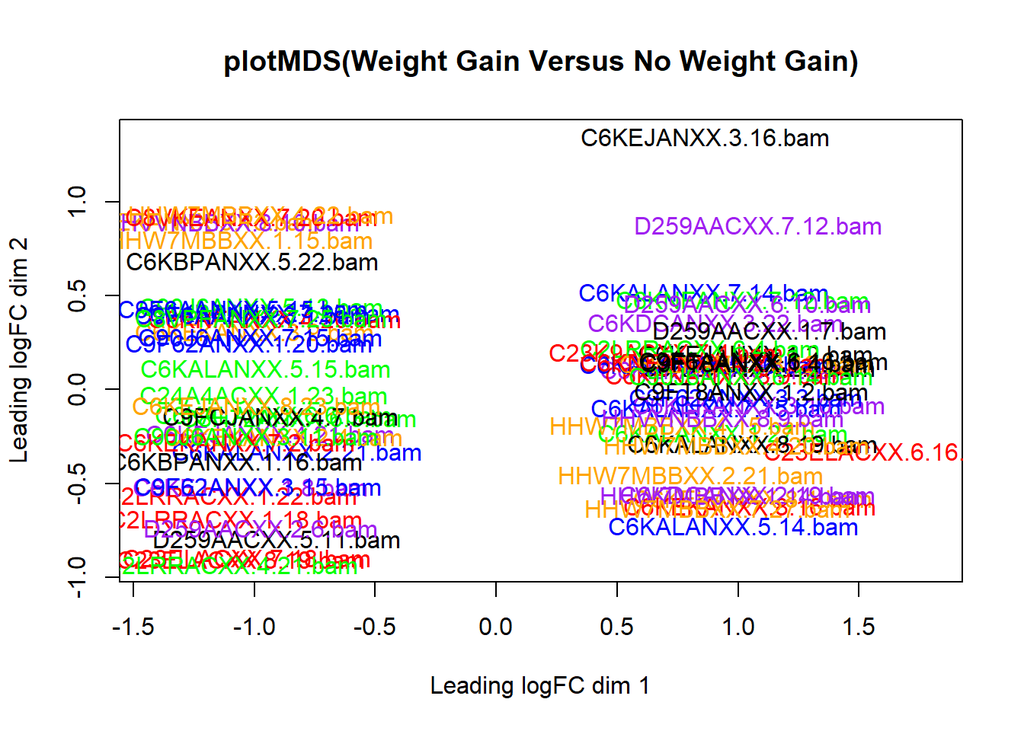

```r
plotMDS(v.total, main="plotMDS(Weight Gain Versus No Weight Gain)",cex=1,col=c(rep("red",3),rep("green",3),rep("blue",3),rep("black",3), rep("purple",3), rep("orange",3)))
```

#MDS Plots

```r
png(file="mygraphic.png",width=1000,height=750)
plotMDS(v, main="Weight Gain Two Clusters",cex=1,col=c(rep("red",3),rep("green",3),rep("blue",3),rep("black",3), rep("purple",3), rep("orange",3)), fontsz= 20)
dev.off()
```

```r
png(file="mygraphic2.png",width=1000,height=500)
plotMDS(v.total, main="plotMDS(Weight Gain Versus No Weight Gain)",cex=1,col=c(rep("red",3),rep("green",3),rep("blue",3),rep("black",3), rep("purple",3), rep("orange",3)))
dev.off()
```

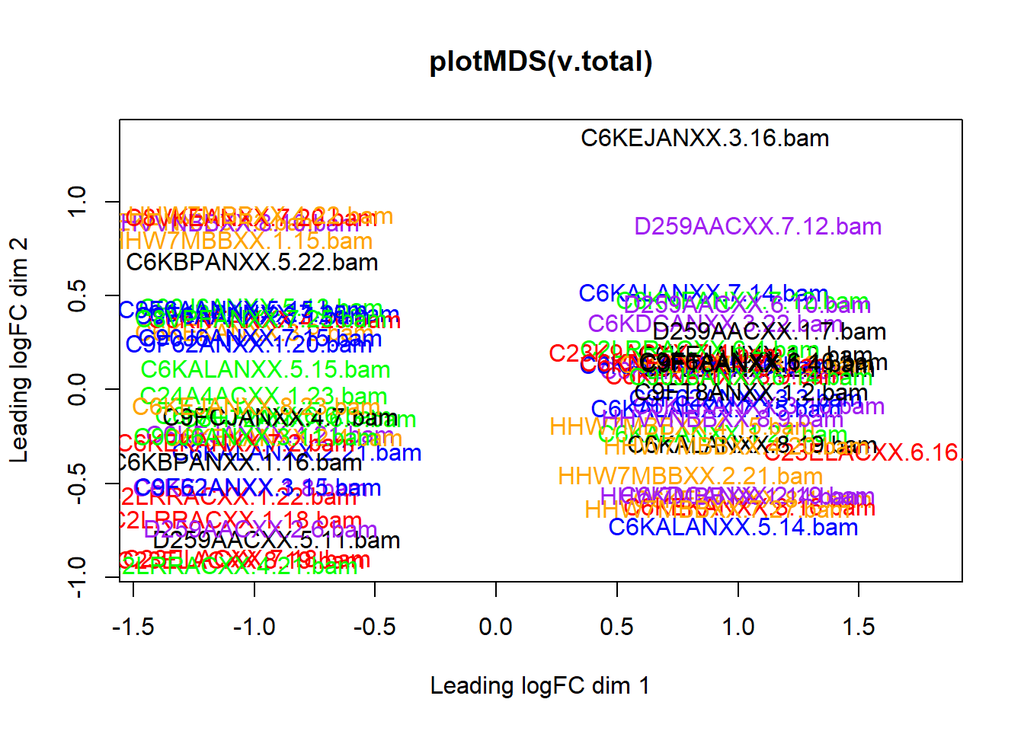

```r
plotMDS(v.total, main="plotMDS(v.total)",cex=1,col=c(rep("red",3),rep("green",3),rep("blue",3),rep("black",3), rep("purple",3), rep("orange",3)))
```

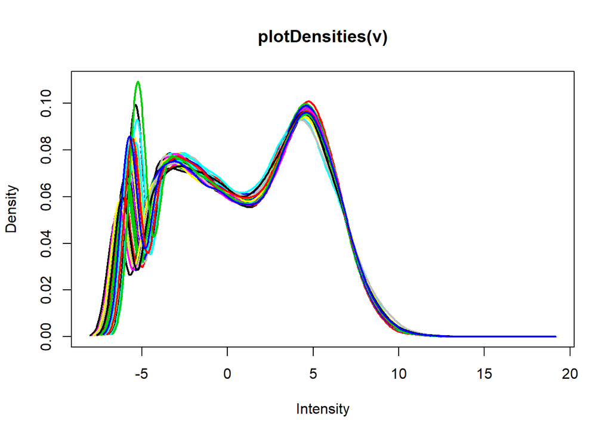

```r
plotDensities(v, main="plotDensities(v)",legend=F)
```

## Had paired information been available, I would have used a design like this

```r
library(readr)
Experiment_Design_factorial<- read_csv("Experiment_Design_Factorial.csv")
Experiment_Design_total= as.data.frame(Experiment_Design_factorial)
(Experiment_Design_factorial)
```

```
## # A tibble: 72 x 3
##    stressor Time  name
##    <chr>    <chr> <chr>
##  1 WG       B     C23ELACXX_8_19.bam
##  2 WG       B     C2LRRACXX_1_18.bam
##  3 WG       B     C2LRRACXX_1_22.bam
##  4 WG       A     C6KALANXX_1_27.bam
##  5 WG       B     C6KALANXX_5_15.bam
##  6 WG       B     C6KALANXX_6_6.bam
##  7 WG       A     C6KALANXX_7_14.bam
##  8 WG       A     C6KALANXX_7_15.bam
##  9 WG       B     C6KBPANXX_7_25.bam
## 10 WG       A     C6KEJANXX_1_2.bam
## # ... with 62 more rows
```

```r
Experiment_Design_factorial$stressor <- as.factor(Experiment_Design_factorial$stressor)
Experiment_Design_factorial$Time = as.factor(Experiment_Design_factorial$Time)
#Experiment_Design$name<- as.factor(Experiment_Design$name)
#str(Experiment_Design_factorial)  # check dataframe structure
Experiment_Design_factorial$stressor <- relevel(Experiment_Design_factorial$stressor, "NWG")
Experiment_Design_factorial$Time= relevel(Experiment_Design_factorial$Time, "B")
str(Experiment_Design_factorial)
```

```
## Classes 'spec_tbl_df', 'tbl_df', 'tbl' and 'data.frame': 72 obs. of  3 variables:
##  $ stressor: Factor w/ 2 levels "NWG","WG": 2 2 2 2 2 2 2 2 2 2 ...
##  $ Time    : Factor w/ 2 levels "B","A": 1 1 1 2 1 1 2 2 1 2 ...
##  $ name    : chr  "C23ELACXX_8_19.bam" "C2LRRACXX_1_18.bam" "C2LRRACXX_1_22.bam" "C6KALANXX_1_27.bam" ...
##  - attr(*, "spec")=
##   .. cols(
##   ..   stressor = col_character(),
##   ..   Time = col_character(),
##   ..   name = col_character()
##   .. )
```

```r
design_factorial <- model.matrix(~stressor+Time, data=Experiment_Design_factorial)  # get design matrix corresponding to a factorial model formula
```

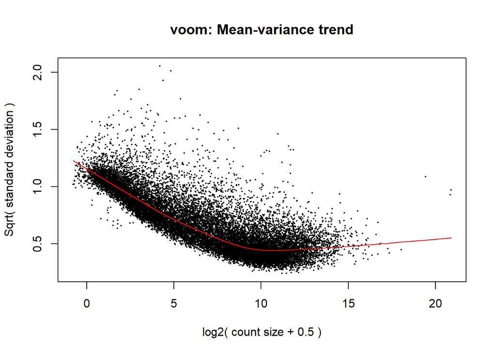

```r
v.factorial= voom(dge_normalised_total,design_factorial,plot=TRUE) # Note: optionally, we can pass library sizes explicity here
```

## Fit linear models across all genes using lmFit

(like lm() in base R)

```r
fit.factorial <- lmFit(v.factorial,design_factorial)
```

## eBayes computes F (overall “omnibus” p-values) and (moderated) t-statistics for all genes

(like anova() in base R)

```r
fit2.factorial  <- eBayes(fit.factorial, trend = TRUE, robust = TRUE)
colnames(fit2.factorial)
```

```
## [1] "(Intercept)" "stressorWG"  "TimeA"
```

# Do FDR multiple testing correction and extract list of most significant genes (using Benjamini-Hockberg by default)

```r
#R_interaction = topTable(fit2.factorial, coef="stressorWG:TimeA", number=nrow(dge_normalised_total$counts))
R_NWG_vs_WG_in_TimeB = topTable(fit2.factorial, coef="stressorWG", number=nrow(dge_normalised_total$counts))
R_B_vs_A_in_NWG = topTable(fit2.factorial, coef="TimeA", number=nrow(dge_normalised_total$counts))
```

## How many significant genes showing interaction are there at FDR of 5% ?

## How many significant genes showing interaction are there at FDR of 5% ?

```r
R2f= (R_NWG_vs_WG_in_TimeB [R_NWG_vs_WG_in_TimeB$adj.P.Val <= 0.05,])
dim(R2f)
```

```
## [1] 71  6
```

## How many significant genes showing interaction are there at FDR of 5% ?

```r
R3f=R_B_vs_A_in_NWG [R_B_vs_A_in_NWG$adj.P.Val<= .05,]

dim(R3f)
```

```
## [1] 576   6
```

```r
length(TotalCountsNCBI[,1])
```

```
## [1] 38557
```

```r
GSEA.NormalizeRows <-
function(V) {
  # Takes as input a matrix or dataframe with raw read counts. Each row represents reads for a single gene. Each column is reads from a single sample for all genes
#The function assumed that each row of count data represents reads for a single gene for all samples. The mean and standard deviation for each row was calculated.
 row.mean <- apply(V, MARGIN = 1, FUN = mean)  # mean for each row calculated. This is the mean counts for a given gene
 row.sd <- apply(V, MARGIN = 1, FUN = sd) # the standard deviation for the read count for each gene is calculated
 row.n <- length(V[, 1]) # this is the number of rows in the counts dataframe
 for (i in 1:row.n) {
  if (row.sd[i] == 0) {   # if standard deviation is zero, then all read counts should be equated to zero
   V[i, ] <- 0
  } else {  # is sd is not zeor, then for each read in a given row, substract the row mean from it and then divide the answer by the standard deviation of that row.
   V[i, ] <- (V[i, ] - row.mean[i])/row.sd[i]  # replaced the raw read count by this normalised score
  }
 }
 return(V)
}
```

```r
Normalised_Data= GSEA.NormalizeRows(TotalCountsNCBI)
```

```r
write.csv(Normalised_Data, file= "Normalised_Data.csv")
```